# Chi-Square and F Distributions

Colin Quirk

4/16/2020

In this tutorial, we are going to be looking at the chi-square distribution, how it relates to the F distribution, and finally how these distributions relate to regression. Why is this distribution so important? Well, the sum of squares of a number of independent, standard normal random variables takes on the shape of a chi-square distribution. Remember how we assume our models have normally distributed, independent residuals? This allows us to assume that the sum of squares of those residuals are distributed as a chi-square distribution (after standardizing them).

## Definition of the chi-square distribution

The chi-square distribution has a single parameter, k, which represents degrees of freedom. Because we are squaring our normally distributed random variables, the chi-square distribution cannot be negative. As k increases, the sum of all the values is pushed higher.

[figure not shown]

Briefly, let’s simulate some data to gain an intuition for what this plot is telling us. For k = 1, we are getting a single random normal variable and squaring it. A normally distributed variable is likely to be close to zero, so the square of that variable is also likely to be close to zero.

```r
x = replicate(100, sum(rnorm(1)^2))

head(x)
```

```
## [1] 1.87952706 0.31888402 0.13186224 0.40051508 0.16343288 0.01126241
```

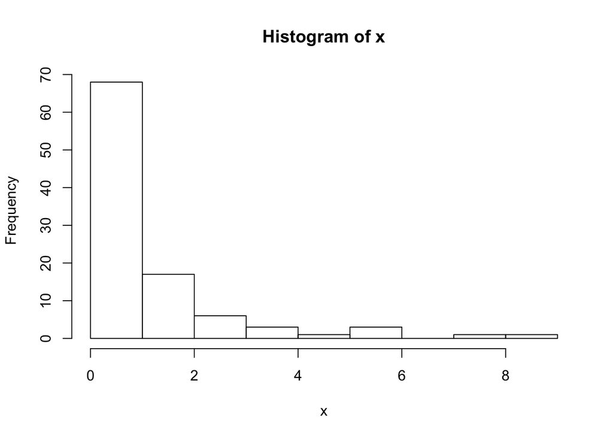

```r
hist(x)
```

Now, let’s think about k = 5. Each individual variable is still likely to be close to 0, but the sum of them slowly push to the right. Additionally, there is a higher chance of an outlier which, due to the square, will have a large impact on the sum.

```r
x = replicate(100, sum(rnorm(5)^2))

head(x)
```

```
## [1] 7.4017224 0.2540187 3.2614418 9.5834042 5.4019407 6.1915526
```

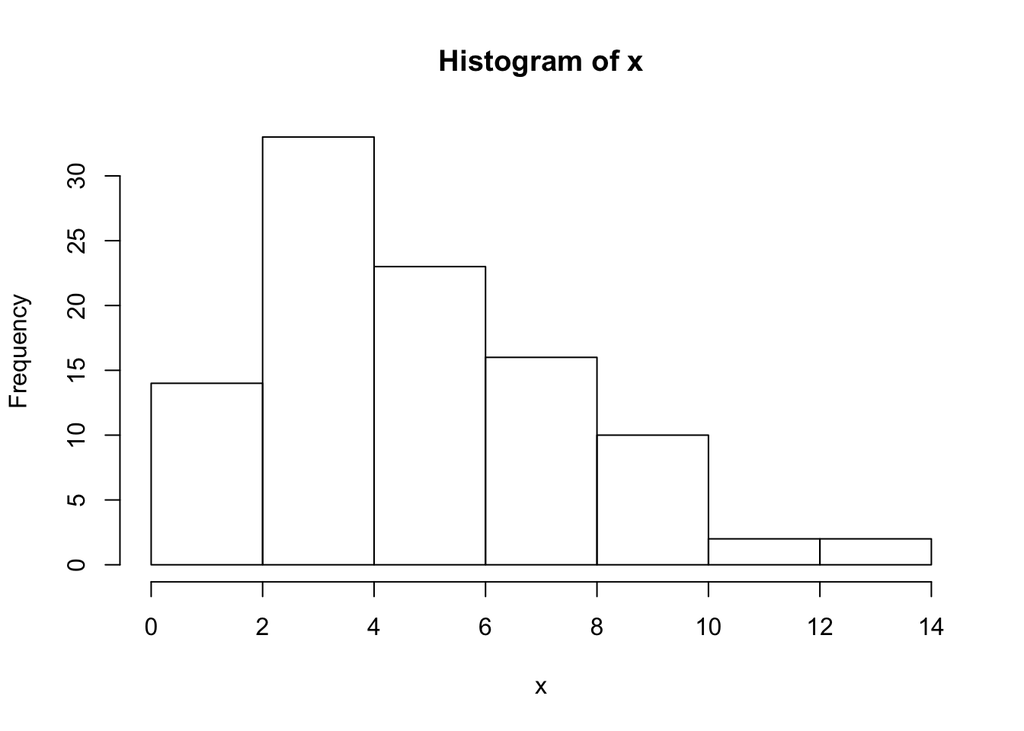

```r
hist(x)
```

## Chi-square test

Most of you probably know of the chi-square distribution in relation to the chi-square test, which is used to determine significance if you are working with categorical data in a contingency table. I want to show how to do this test in R briefly, in case you ever need it. Under the null hypothesis that there is no association between your categorical variables, your expected deviation has a chi-square distribution.

Here is a quick example. Imagine we asked 100 men and 100 women if they like cats and our data looked like this.

```r
cats = as.table(matrix(c(54, 82, 46, 18), ncol=2))
colnames(cats) = c("Likes cats", "Does not like cats")
rownames(cats) = c("male", "female")

knitr::kable(cats)
```

|  | Likes cats | Does not like cats |
| --- | --- | --- |
| male | 54 | 46 |
| female | 82 | 18 |

To calculate our chi-square test statistic, we the sum of the residuals squared divided by the expected value.

```r
expected = outer(rowSums(cats), colSums(cats), "*") / 200
sum(((cats - expected)^2) / expected)
```

```
## [1] 18.01471
```

To generate a p-value, we use `pchisq`.

```r
pchisq(18, df = 1, lower.tail = FALSE)
```

```
## [1] 2.20905e-05
```

We can check our work using `chisq.test`.

```r
chisq.test(cats, correct = FALSE)
```

```
##
##  Pearson's Chi-squared test
##
## data:  cats
## X-squared = 18.015, df = 1, p-value = 2.192e-05
```

## Chi-square in the T-distribution

The Chi-square distribution is actually an important piece of the t-distribution. You can think of the t-distribution as N / sqrt(V / k) where N is the standard normal, V being a chi-square distribution with k degrees of freedom. Here is a plot comparing the standard normal distribution to a t-distribution with df = 3.

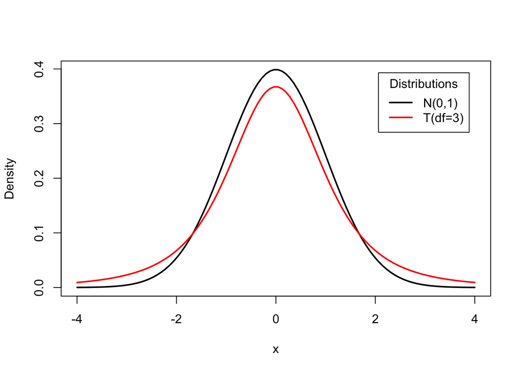

Let’s now sample from the t-distribution using `rnorm` and `rchisq` instead of `rt`. We will plot a QQ plot which compares our sampled data to the theoretical t-distribution.

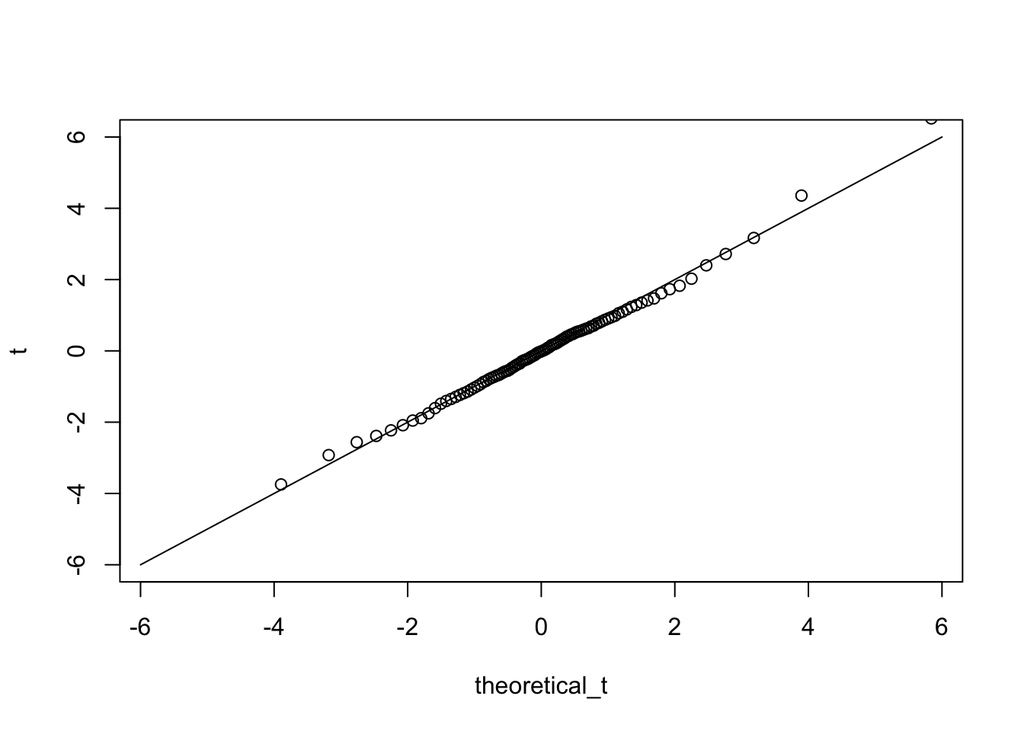

```r
norms = rnorm(1000)
chis = rchisq(1000, df = 3)

t = norms / sqrt(chis / 3)
theoretical_t = qt(ppoints(100), df=3)

qqplot(theoretical_t, t, ylim = c(-6, 6))
lines(seq(-6, 6, length.out=100), seq(-6, 6, length.out=100))
```

The fact that our points fall nearly perfectly onto the line suggests that our distibution is nearly perfectly aligned with the theoretical t-distribution.

## Chi-square distribution in Regression

In a regression, our overall test statistic comes from an F distribution. The F distribution is the ratio of two independent chi-square distributions. A ratio of two positive numbers is also positive, so the F distribution is also nonnegative.

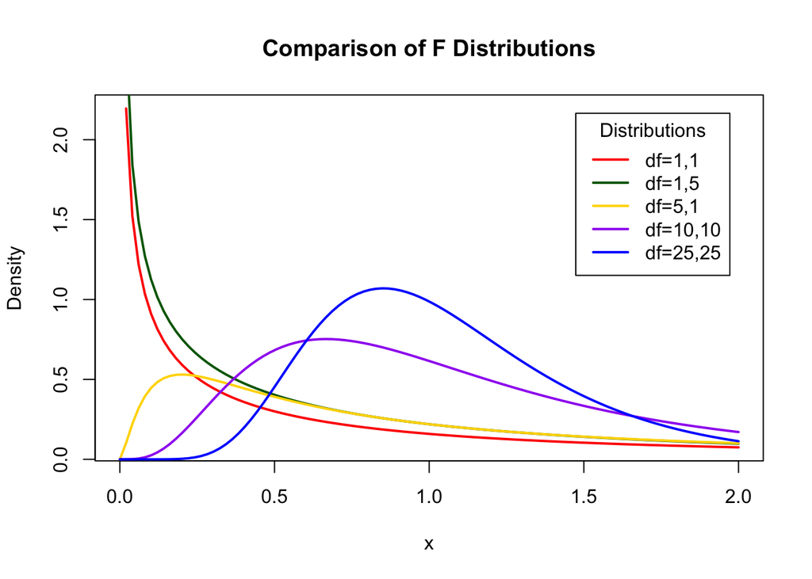

Let’s generate samples from F(5, 5) using rchisq as we did with the T-distribution.

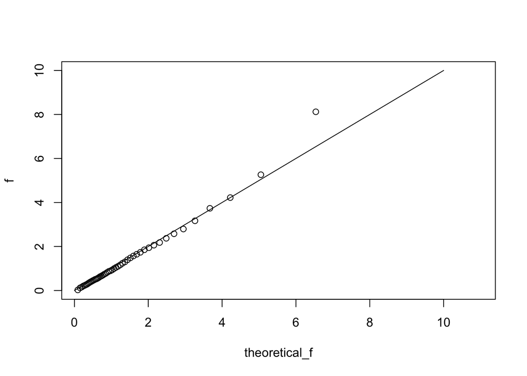

```r
chi1 = rchisq(1000, df = 5) / 5
chi2 = rchisq(1000, df = 5) / 5

f = chi1 / chi2
theoretical_f = qf(ppoints(50), 5, 5)

qqplot(theoretical_f, f, ylim = c(0, 10))
lines(seq(0, 10, length.out=100), seq(0, 10, length.out=100))
```

As you can see, our sampled data closely fits an F(5, 5) distribution. Finally, let’s use the F distribution to calculate if a regression model is significant by hand.

```r
head(iris)
```

```
##   Sepal.Length Sepal.Width Petal.Length Petal.Width Species
## 1          5.1         3.5          1.4         0.2  setosa
## 2          4.9         3.0          1.4         0.2  setosa
## 3          4.7         3.2          1.3         0.2  setosa
## 4          4.6         3.1          1.5         0.2  setosa
## 5          5.0         3.6          1.4         0.2  setosa
## 6          5.4         3.9          1.7         0.4  setosa
```

```r
fit = lm(Petal.Length ~ Petal.Width, data=iris)

fit$coefficients
```

```
## (Intercept) Petal.Width
##    1.083558    2.229940
```

```r
iris_with_predictions = iris %>%
  mutate(reg_pred = fit$coefficients[1] + fit$coefficients[2] * Petal.Width,
         null_pred = mean(Petal.Length),  # null model just predicts the mean
         reg_res = reg_pred - Petal.Length,
         null_res = null_pred - Petal.Length)

head(iris_with_predictions)
```

```
##   Sepal.Length Sepal.Width Petal.Length Petal.Width Species reg_pred
## 1          5.1         3.5          1.4         0.2  setosa 1.529546
## 2          4.9         3.0          1.4         0.2  setosa 1.529546
## 3          4.7         3.2          1.3         0.2  setosa 1.529546
## 4          4.6         3.1          1.5         0.2  setosa 1.529546
## 5          5.0         3.6          1.4         0.2  setosa 1.529546
## 6          5.4         3.9          1.7         0.4  setosa 1.975534
##   null_pred    reg_res null_res
## 1     3.758 0.12954613    2.358
## 2     3.758 0.12954613    2.358
## 3     3.758 0.22954613    2.458
## 4     3.758 0.02954613    2.258
## 5     3.758 0.12954613    2.358
## 6     3.758 0.27553423    2.058
```

```r
(df_r = 1)  # Petal.Width coef, plus intercept, minus 1
```

```
## [1] 1
```

```r
(df_e = nrow(iris) - 2)
```

```
## [1] 148
```

```r
(SSE = sum(iris_with_predictions$reg_res^2))
```

```
## [1] 33.84475
```

```r
(SSR = sum(iris_with_predictions$null_res^2) - SSE)
```

```
## [1] 430.4806
```

```r
(MSR  = SSR / df_r)
```

```
## [1] 430.4806
```

```r
(MSE  = SSE / df_e)
```

```
## [1] 0.2286808
```

```r
(f_val = MSR / MSE)
```

```
## [1] 1882.452
```

Our F value is over 1000, we can use `pf` to get our p-value.

```r
pf(f_val, df_r, df_e, lower.tail = FALSE)
```

```
## [1] 4.675004e-86
```

Let’s use lm to check our work.

```r
summary(fit)
```

```
##
## Call:
## lm(formula = Petal.Length ~ Petal.Width, data = iris)
##
## Residuals:
##      Min       1Q   Median       3Q      Max
## -1.33542 -0.30347 -0.02955  0.25776  1.39453
##
## Coefficients:
##             Estimate Std. Error t value Pr(>|t|)
## (Intercept)  1.08356    0.07297   14.85   <2e-16 ***
## Petal.Width  2.22994    0.05140   43.39   <2e-16 ***
## ---
## Signif. codes:  0 '***' 0.001 '**' 0.01 '*' 0.05 '.' 0.1 ' ' 1
##
## Residual standard error: 0.4782 on 148 degrees of freedom
## Multiple R-squared:  0.9271, Adjusted R-squared:  0.9266
## F-statistic:  1882 on 1 and 148 DF,  p-value: < 2.2e-16
```

Spoiler for the future, the math here is similar to an anova. You can use the anova function to check your math.

```r
anova(fit)
```

```
## Analysis of Variance Table
##
## Response: Petal.Length
##              Df Sum Sq Mean Sq F value    Pr(>F)
## Petal.Width   1 430.48  430.48  1882.5 < 2.2e-16 ***
## Residuals   148  33.84    0.23
## ---
## Signif. codes:  0 '***' 0.001 '**' 0.01 '*' 0.05 '.' 0.1 ' ' 1
```